# Trabajo 2

- Mostrar todo el código
- Ocultar todo el código
- Ver el código fuente

Series de Tiempo — Pregrado en Estadística, UNAL Medellín

Autores/as

Afiliación

Julian Esteban Ariza Caro

Departamento de Estadística - UNALMED

Sebastián Valencia Botero

Fecha de publicación

27 de noviembre de 2026

# 1 Serie 1

**Mostrar/ocultar código**

```r
# Pacientes original

Serie_1 <- leer_serie("../datos/ST4HTU-serie-1.csv", "Red de Salud de Valdeflores", "Pacientes")
```

## 1.1 1 ficha tecnica a

**Mostrar/ocultar código**

```r
ficha_st1 <- crear_ficha(Serie_1, "Pacientes promedio", " # de pacientes")

tabla_ficha1 <- kable(ficha_st1, booktabs = TRUE, align = c("l", "l"),
      caption = "Ficha técnica - Serie 1") |>
  kable_styling(latex_options = c("hold_position"),
                full_width = FALSE)
tabla_ficha1
```

Ficha técnica - Serie 1

| Característica | Valor |
| --- | --- |
| Nombre | Pacientes promedio |
| Unidad | # de pacientes |
| Frecuencia | Mensual |
| Fecha inicial | 2016-12-01 |
| Fecha final | 2026-06-01 |
| T (observaciones) | 115 |
| Mínimo | 3287 |
| Máximo | 13032 |
| Media | 8107.7 |

## 1.2 2 contexto b

## 1.3 3 Escala y estabilizacion

### 1.3.1 a

**Mostrar/ocultar código**

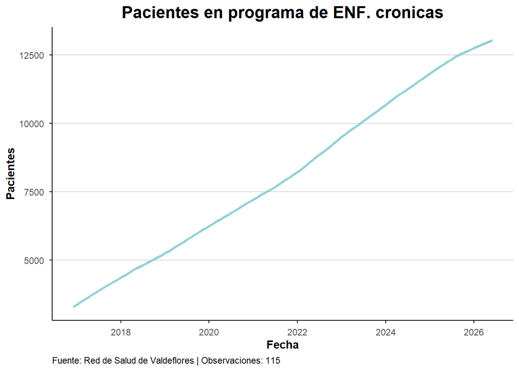

```r
graficar_serie(Serie_1, "Pacientes en programa de ENF. cronicas", mostrar_puntos = FALSE)
```

**Mostrar/ocultar código**

```
$acf
 [1] 0.9756770 0.9511969 0.9265666 0.9017930 0.8768824 0.8518558 0.8267191
 [8] 0.8014737 0.7761310 0.7507129 0.7252316 0.6997189 0.6742169 0.6487475
[15] 0.6233424 0.5980140 0.5727704 0.5476251 0.5225617 0.4975876 0.4727101
[22] 0.4479267 0.4232291 0.3986336

$panel
```

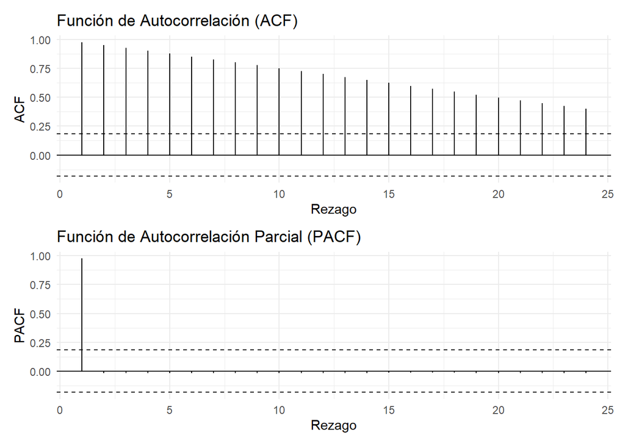

```
$diferencia_maxima
[1] 0.5525633
```

```r
correlograma(Serie_1)
```

**Mostrar/ocultar código**

```r
disp_st1 <- pendiente_dispersion(Serie_1, k = 5)

cat("Pendiente =", round(disp_st1$pendiente, 3),
    "  λ = 1 − pendiente =", round(disp_st1$lambda, 3))
```

```
Pendiente = 0.801   λ = 1 − pendiente = 0.199
```

**Mostrar/ocultar código**

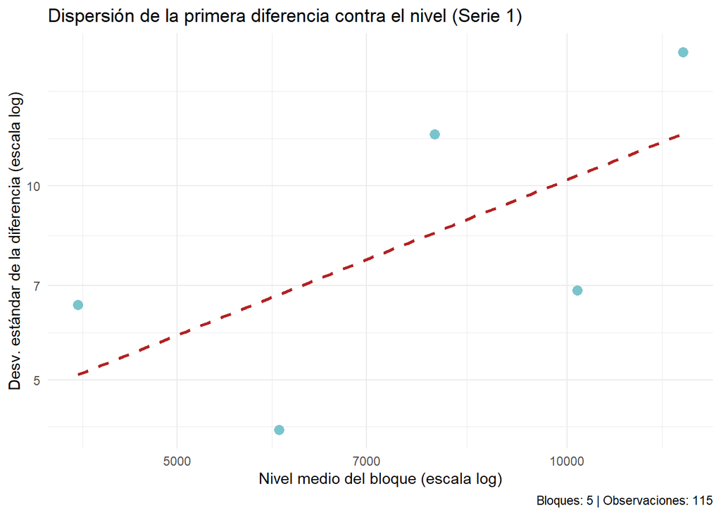

```r
ggplot(disp_st1$tabla, aes(x = nivel, y = desv_dif)) +
  geom_point(size = 3, color = "#7AC5CD") +
  geom_smooth(method = "lm", se = FALSE, color = "firebrick", linetype = "dashed") +
  scale_x_log10() +
  scale_y_log10() +
  labs(title = "Dispersión de la primera diferencia contra el nivel (Serie 1)",
       x = "Nivel medio del bloque (escala log)",
       y = "Desv. estándar de la diferencia (escala log)",
       caption = paste("Bloques:", nrow(disp_st1$tabla), "| Observaciones:",
                       nrow(Serie_1))) +
  theme_minimal()
```

### 1.3.2 b perfil log

**Mostrar/ocultar código**

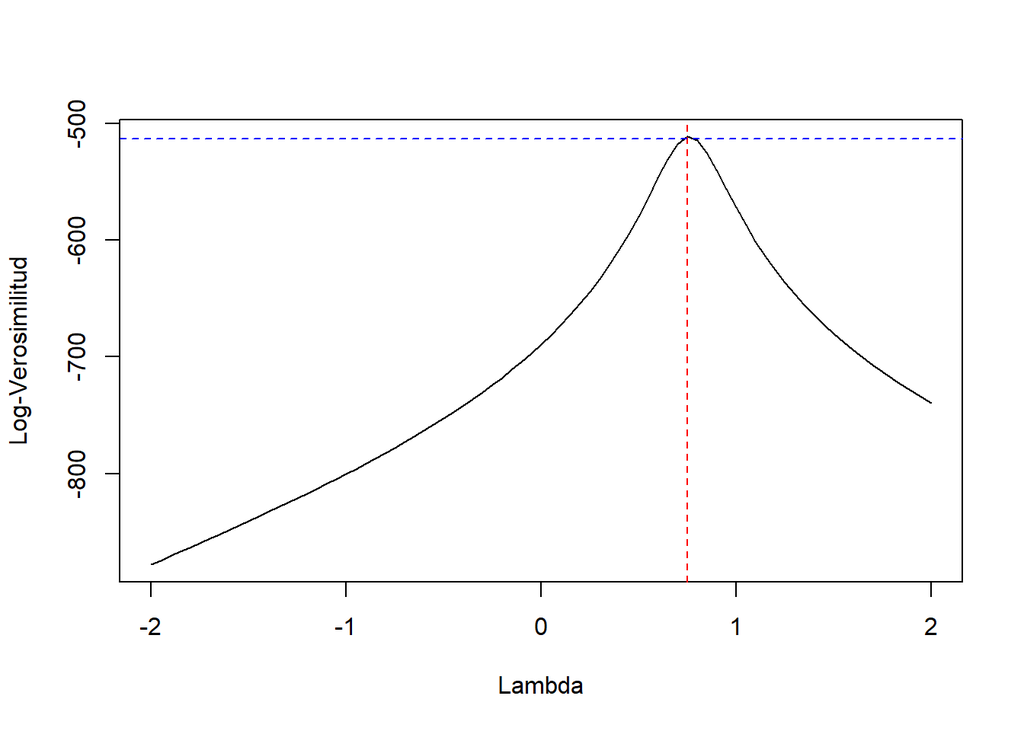

```r
res_lambda <- perfil_lambda(Serie_1)     # gráfico del perfil con jacobiano
```

**Mostrar/ocultar código**

```r
cat("λ̂ =", res_lambda$lambda_optimo,
    "  IC 95 % = [", round(res_lambda$ic_95[1], 2), ",",
    round(res_lambda$ic_95[2], 2), "]\n")
```

```
λ̂ = 0.75   IC 95 % = [ 0.75 , 0.75 ]
```

**Mostrar/ocultar código**

```r
# Valores "simples" dentro del IC
candidatos_lambda <- c(-1, -0.5, 0, 0.5, 1)
candidatos_lambda[candidatos_lambda >= res_lambda$ic_95[1] &
                  candidatos_lambda <= res_lambda$ic_95[2]]
```

```
numeric(0)
```

**Mostrar/ocultar código**

```r
# Valores no positivos: la familia Box-Cox exige Z > 0
any(Serie_1$y <= 0)
```

```
[1] FALSE
```

**Mostrar/ocultar código**

```r
lambda_st1 <- 0.75           # sección 3(b): valor redondeado dentro del IC del 95 %
```

### 1.3.3 c Transformada y diferenciada

**Mostrar/ocultar código**

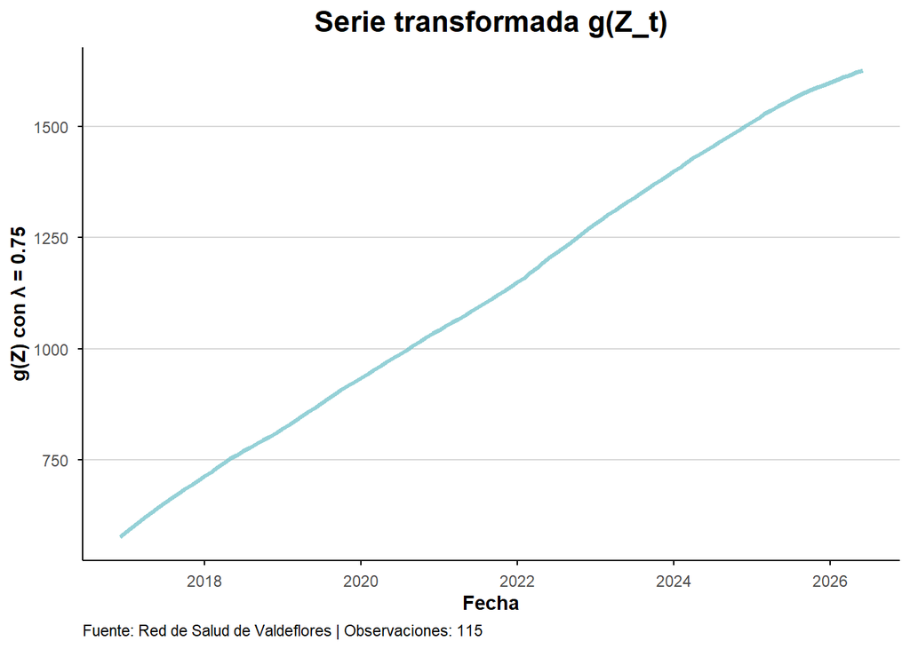

```r
gZ_st1 <- boxcox_tr(Serie_1$y, lambda_st1)

Serie_1_g <- boxcox_tr(Serie_1, lambda_st1)
attr(Serie_1_g, "unidad") <- paste0("g(Z) con λ = ", lambda_st1)
graficar_serie(Serie_1_g, "Serie transformada g(Z_t)", mostrar_puntos = FALSE)
```

**Mostrar/ocultar código**

```r
# Crecimiento porcentual aproximado: 100 ∇ ln Z_t frente al cambio porcentual exacto
cmp_crec <- data.frame(
  aprox_log  = 100 * diff(log(Serie_1$y)),
  exacto_pct = 100 * diff(Serie_1$y) / head(Serie_1$y, -1)
)
summary(cmp_crec)
```

```
   aprox_log        exacto_pct
 Min.   :0.4075   Min.   :0.4084
 1st Qu.:0.9332   1st Qu.:0.9376
 Median :1.1402   Median :1.1467
 Mean   :1.2083   Mean   :1.2167
 3rd Qu.:1.4550   3rd Qu.:1.4657
 Max.   :2.6716   Max.   :2.7076
```

## 1.4 4 orden de integracion

### 1.4.1 a

**Mostrar/ocultar código**

```r
niveles_st1 <- list(
  "g(Z_t)"    = gZ_st1,
  "∇ g(Z_t)"  = diferenciar(gZ_st1, 1),
  "∇² g(Z_t)" = diferenciar(gZ_st1, 2)
)

tabla_var_st1 <- data.frame(
  serie    = names(niveles_st1),
  n        = unname(sapply(niveles_st1, length)),
  varianza = unname(sapply(niveles_st1, var)),
  r1       = unname(sapply(niveles_st1, function(v)
               stats::acf(v, lag.max = 1, plot = FALSE)$acf[2]))
)
kable(tabla_var_st1, digits = 4, booktabs = TRUE,
      caption = "Varianza y r₁ de g(Z_t) y sus diferencias") |>
  kable_styling(latex_options = "hold_position")
```

Varianza y r₁ de g(Z_t) y sus diferencias

| serie | n | varianza | r1 |
| --- | --- | --- | --- |
| g(Z_t) | 115 | 98593.6255 | 0.9751 |
| ∇ g(Z_t) | 114 | 2.0237 | 0.9134 |
| ∇² g(Z_t) | 113 | 0.1338 | 0.4991 |

**Mostrar/ocultar código**

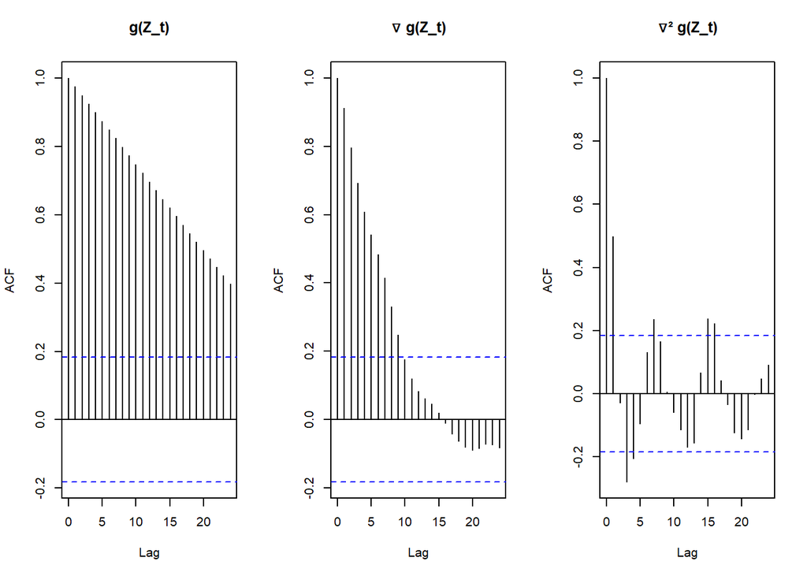

```r
op <- par(mfrow = c(1, 3))
for (nm in names(niveles_st1)) stats::acf(niveles_st1[[nm]], lag.max = 24, main = nm)
```

**Mostrar/ocultar código**

```r
par(op)
```

### 1.4.2 b dickye fuller aumentada

**Mostrar/ocultar código**

```r
# Paso 0: especificación determinista según el gráfico y la regresión sobre el tiempo
t_st1 <- seq_along(gZ_st1)
summary(lm(gZ_st1 ~ t_st1))$coefficients
```

```
              Estimate Std. Error  t value      Pr(>|t|)
(Intercept) 577.260527 1.73744221 332.2473 8.381781e-171
t_st1         9.413476 0.02599866 362.0754 5.106514e-175
```

**Mostrar/ocultar código**

```r
# Número máximo de rezagos: regla de Schwert (1989)
pmax_st1 <- floor(12 * (length(gZ_st1) / 100)^(1 / 4))

# Paso 1: g(Z_t)
df_nivel <- tabla_df_secuencial(gZ_st1, pmax = pmax_st1, criterio = "AIC")
df_nivel
```

| especificacion | p | N | tau | valor_critico_05 | rechaza_H0 |
| --- | --- | --- | --- | --- | --- |
| Con constante y tendencia | 7 | 102 | -1.390348 | -3.45 | FALSE |
| Con constante | 7 | 102 | -1.539744 | -2.89 | FALSE |
| Sin constante ni tendencia | 4 | 102 | -1.318371 | -1.95 | FALSE |

**Mostrar/ocultar código**

```r
# Paso 2: primera diferencia
df_dif1 <- tabla_df_secuencial(diferenciar(gZ_st1, 1), pmax = pmax_st1, criterio = "AIC")
df_dif1
```

| especificacion | p | N | tau | valor_critico_05 | rechaza_H0 |
| --- | --- | --- | --- | --- | --- |
| Con constante y tendencia | 6 | 101 | -0.8149730 | -3.45 | FALSE |
| Con constante | 6 | 101 | -0.4901610 | -2.89 | FALSE |
| Sin constante ni tendencia | 6 | 101 | -0.9538866 | -1.95 | FALSE |

**Mostrar/ocultar código**

```r
# Paso 3: segunda diferencia, solo si la primera no es estacionaria
df_dif2 <- tabla_df_secuencial(diferenciar(gZ_st1, 2), pmax = pmax_st1, criterio = "AIC")
df_dif2
```

| especificacion | p | N | tau | valor_critico_05 | rechaza_H0 |
| --- | --- | --- | --- | --- | --- |
| Con constante y tendencia | 5 | 100 | -3.752696 | -3.45 | TRUE |
| Con constante | 5 | 100 | -3.608808 | -2.89 | TRUE |
| Sin constante ni tendencia | 5 | 100 | -3.444101 | -1.95 | TRUE |

**Mostrar/ocultar código**

```r
d_st1      <- 2           # sección 4(b): número de diferencias
espec_st1  <- "trend"     # sección 4(b): "none", "drift" o "trend"
```

### 1.4.3 c recta vs diferencia

**Mostrar/ocultar código**

```r
# Decisión de la prueba con tendencia sobre g(Z)
if (df_nivel$rechaza_H0[1]) {
  cat("Rechaza raíz unitaria con tendencia: estacionaria alrededor de una recta\n")
} else {
  cat("No rechaza con tendencia: tendencia estocástica, diferenciar\n")
}
```

```
No rechaza con tendencia: tendencia estocástica, diferenciar
```

**Mostrar/ocultar código**

```r
# Si es estacionaria alrededor de la recta: residuo de la regresión sobre t
if (espec_st1 == "trend") {
  ajuste_recta_st1 <- lm(gZ_st1 ~ t_st1)
  W_recta_st1      <- resid(ajuste_recta_st1)
}

# Alternativa que NO se elige: diferenciar una serie trend-stationary
diff_alt_st1 <- diferenciar(gZ_st1, 1)
c(sd_recta = sd(resid(lm(gZ_st1 ~ t_st1))), sd_dif = sd(diff_alt_st1))
```

```
sd_recta   sd_dif
9.214622 1.422554
```

### 1.4.4 d constante serie ya diferenciada

**Mostrar/ocultar código**

```r
W_dif_st1 <- diferenciar(gZ_st1, d_st1)
mu_hat    <- mean(W_dif_st1)
N_w       <- length(W_dif_st1)
L_nw      <- floor(4 * (N_w / 100)^(2 / 9))
se_nw     <- se_media_nw(W_dif_st1, L_nw)
t_mu      <- mu_hat / se_nw
p_mu      <- 2 * pt(-abs(t_mu), df = N_w - 1)

c(media = mu_hat, EE_NW = se_nw, L = L_nw, t = t_mu, p_valor = p_mu)
```

```
      media       EE_NW           L           t     p_valor
-0.05975026  0.04133473  4.00000000 -1.44552197  0.15110366
```

**Mostrar/ocultar código**

```r
# Lectura en unidades del problema (si λ = 0): crecimiento mensual medio en %
100 * mu_hat
```

```
[1] -5.975026
```